# Mutational Signatures in RNA-seq from Ovarian Cancer

## Preliminary functions

The following functions allow us to load and analyze mutational signatures

```r
# Loads a mutational signature matrix from a mutational signature txt file
load_old_mutational_matrix<-
  function(filename,
          mut.order="supplied_data/mut_sig.order.csv") {
  mutational.signature <-  read_csv(filename)
  mut_mat <-  read_csv(mut.order)

  mut.join <-  mutational.signature %>%
    inner_join(mut_mat)

  order.tri <-  unique(mut.join$ext.context)

  mut.join <-  mut.join %>%
    mutate(ext.context = factor (ext.context, levels = order.tri)) %>%
    select(ext.context,prob)

  mut.matrix <-  as.matrix(
        sapply(mut.join[,2:ncol(mut.join)], as.numeric))

  rownames(mut.matrix) <-  mut.join$ext.context

  return (t(mut.matrix)[,1:96])
}

change_old_mutational_matrix<-
    function(sig.frame,
             mut.order="supplied_data/mut_sig.order.csv") {

  mutational.signature <-  sig.frame
  mut_mat <-  read_csv(mut.order)

  mut.join <-  mutational.signature %>%
    inner_join(mut_mat)

  order.tri <-  unique(mut.join$ext.context)

  mut.join <-  mut.join %>%
      mutate(ext.context =
                 factor (ext.context, levels = order.tri)) %>%
      select(sample,ext.context,prob) %>%
      pivot_wider(names_from = ext.context,
                  values_from = prob)

    mut.matrix <-  as.matrix(
        sapply(mut.join[,2:ncol(mut.join)], as.numeric))
    rownames(mut.matrix) = mut.join$sample

    return (t(mut.matrix))
}

load_cosmic_matrix<- function(mut.order="supplied_data/mut_sig.order.csv") {

  sp_url <- paste("https://cancer.sanger.ac.uk/cancergenome/assets/",
                "signatures_probabilities.txt", sep = "")

  cancer_signatures <-  read.table(sp_url, sep = "\t", header = TRUE)
  # Match the order of the mutation types to MutationalPatterns standard
  mut_mat <-  read_csv(mut.order)
  new_order <-  match(mut_mat$ext.context, cancer_signatures$Somatic.Mutation.Type)
  # Reorder cancer signatures dataframe
  cancer_signatures <-  cancer_signatures[as.vector(new_order),]
  # Add trinucletiode changes names as row.names
  row.names(cancer_signatures) <-  cancer_signatures$Somatic.Mutation.Type
  # Keep only 96 contributions of the signatures in matrix
  cancer_signatures <- as.matrix(cancer_signatures[,4:33])
  return(cancer_signatures)
}

# Returns a frame with columns Signature, Sample, Contribution with the absolute
# contribution of each signature for each sample
calc_abs_contribution <- function(nmf.res,sig.names) {

  total_signatures <-  colSums(nmf.res$signatures)
  abs_contribution <-  nmf.res$contribution * total_signatures
  rownames(abs_contribution) <- sig.names

  m_contribution <-  melt(abs_contribution)
  colnames(m_contribution) = c("signature", "sample", "contribution")

  return (m_contribution)
}

# Returns a frames with the cosine similarity (fit) between the original profile and the
# reconstructed profile
calc_fit_contribution <- function(mut.matrix,nmf.res) {

  # calculate all pairwise cosine similarities
  cos_sim_ori_rec <- cos_sim_matrix(mut.matrix, nmf.res$reconstructed)
  # extract cosine similarities per sample between original and reconstructed
  fit.table<- as.data.frame(diag(cos_sim_ori_rec))
  fit.table$Sample <-  rownames(fit.table)
  colnames(fit.table) = c("fit","sample")

  return(fit.table)
}

get_top_signature <-function(mut.table, signatures.table,
                             signature,top.n=8,
                             signatures=
                                 c("PolE","Aging","MMR","Germline")){

    # Construct table with only contribution from specific signature
    sig.table <-  mut.table %>%
        gather(signatures,key="sign.name",value="contribution") %>%
        filter(sign.name==signature) %>%
        arrange(desc(contribution))

    # Pick top n samples for that signature
    top.table <-
        sig.table %>% arrange(desc(contribution)) %>%
        head(top.n)

    # Pick signatures for those top samples and plot them
    mut.selected <- top.table %>%
        select(sample) %>%
        inner_join (signatures.table)

    top.signatures <-  change_old_mutational_matrix(mut.selected)
    colnames(top.signatures) <-  paste0("P",1:top.n,"")

    plot.top <-  plot_96_profile(top.signatures)

    return (plot.top)
}
```

## Data acquisition and cleaning

We load the mutational signatures file for all of the samples and consider only samples that have high sequencing coverage (over 5Mb at 20x)

```r
# Load mutational signature data for all samples
signatures <- read_csv(
    "supplied_data/mutational.sig.csv")

# Load sequencing/cohort info for samples, filter with at
# at least 5 million Mb covered
sample.info <-
    read_csv("supplied_data/sample.info.csv") %>%
    filter (area.cov > 5e6)
```

The following table summarizes the number of samples we will be using for the mutational signature analysis

```r
knitr::kable(
  sample.info %>%
    group_by(study) %>%
    summarize(n=n()))
```

| study | n |
| --- | --- |
| Gtex | 84 |
| Mayo | 195 |
| TCGA | 419 |

## Mutational signature analysis

### Initial NMF

We ran the NMF signatures analysis with 4 clusters and plot the resulting mutational signatures

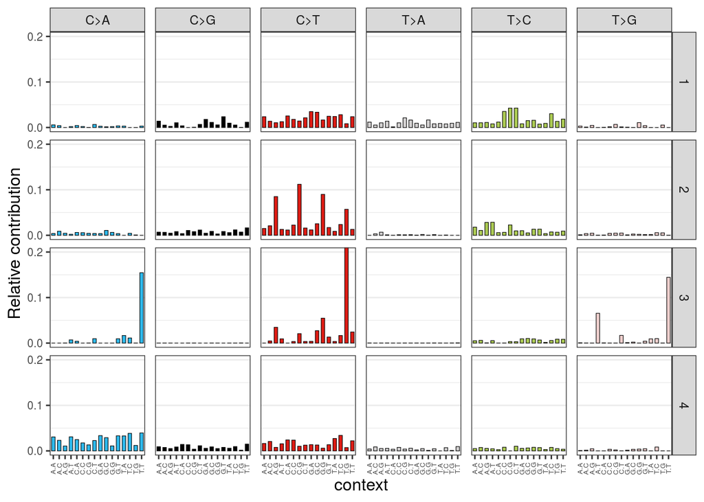

```r
mut.selected <- sample.info %>%
  select (sample) %>%
  inner_join (signatures)

mut_mat <- change_old_mutational_matrix(mut.selected)+ 1e-04

# Do NMF factorization
nclusters <-  4
nmf.res <- extract_signatures(mut_mat, rank = nclusters, nrun = 10)
mut.sig <-  nmf.res$signatures
colnames(mut.sig) <-  seq(1, nclusters)

# Signature plots
plot_96_profile(mut.sig)
```

We adjust the order of the mutational signatures so that they are shown as POLE,MMR,Aging and germline

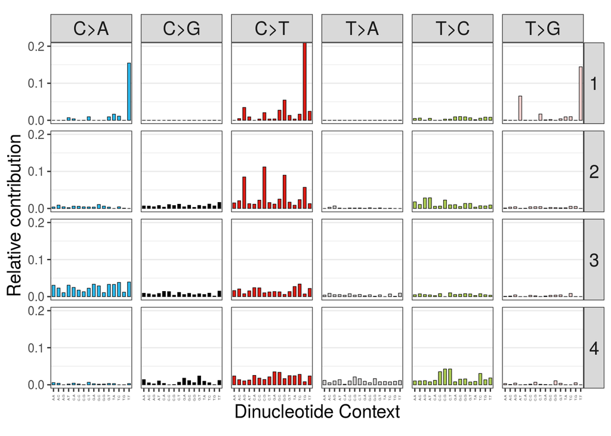

```r
mut.sig <-  mut.sig[,c("3","2","4","1")]
colnames(mut.sig) <-  c(1,2,3,4)

sample.signatures.figure <- plot_96_profile(mut.sig)+
  theme(axis.text.y = element_text(size=10),
        axis.text.x = element_text(size=3),
        axis.title = element_text(size=12),
        strip.text.y = element_text(size=15, angle=0),
        strip.text.x = element_text(size=15, angle=0),
        axis.title.x = element_text(size=15),
        axis.title.y = element_text(size=15),
        aspect.ratio=1)+
  labs(x="Dinucleotide Context")

sample.signatures.figure
```

We compare the mutational signatures against COSMIC mutational signatures v2 and the germline signature

```r
cosmic.signatures <- load_cosmic_matrix()
germline.sig <- load_old_mutational_matrix("supplied_data/germline.sig.csv")
reference.sig <-  cbind (cosmic.signatures[,c(10,6,5)], germline.sig)
sig.labels <-  c("PolE","MMR","Aging","Germ.")
colnames(reference.sig) <- sig.labels

sim.table <-  tibble (signature.id=c(1,2,3,4),
                      signature.ref = sig.labels,
                      cosine.sim=round(
                        diag(cos_sim_matrix(reference.sig,mut.sig)),2))
knitr::kable(sim.table)
```

| signature.id | signature.ref | cosine.sim |
| --- | --- | --- |
| 1 | PolE | 0.88 |
| 2 | MMR | 0.85 |
| 3 | Aging | 0.72 |
| 4 | Germ. | 0.68 |

And we show the relevant COSMIC v2 signatures plus the germline signature profiles

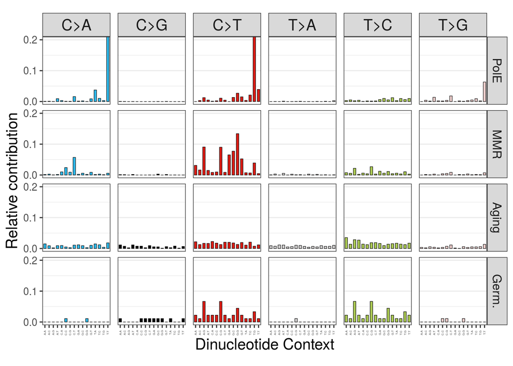

```r
reference.signatures.figure <-
    plot_96_profile(reference.sig) +
    theme(axis.text.y = element_text(size=10),
        axis.text.x = element_text(size=3),
        axis.title = element_text(size=12),
        strip.text.y = element_text(size=12, angle=-90),
        strip.text.x = element_text(size=15, angle=0),
        axis.title.x = element_text(size=15),
        axis.title.y = element_text(size=15),
        aspect.ratio=1)+
        labs(x="Dinucleotide Context")

reference.signatures.figure
```

```r
png ("figures/figure.1.png",
     width=5, height=7, units='in',
     res=300, pointsize=20)

ggarrange(
    sample.signatures.figure,
    reference.signatures.figure,
    labels = c("A","B"),
    ncol=1)

dev.off()
```

And we label appropriately the signatures from the NMF analysis

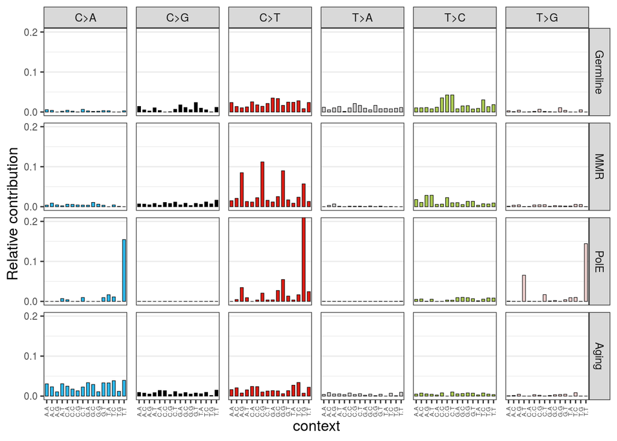

```r
sig.names <- c("Germline","MMR","PolE","Aging")
colnames(nmf.res$signatures)=sig.names
plot_96_profile(nmf.res$signatures)
```

```r
mut.sig <-  nmf.res$signatures
```

### Contributions per signature

We calculate the predicted mutations per Mb per each signature across each sample and visualize their distributions across cohorts

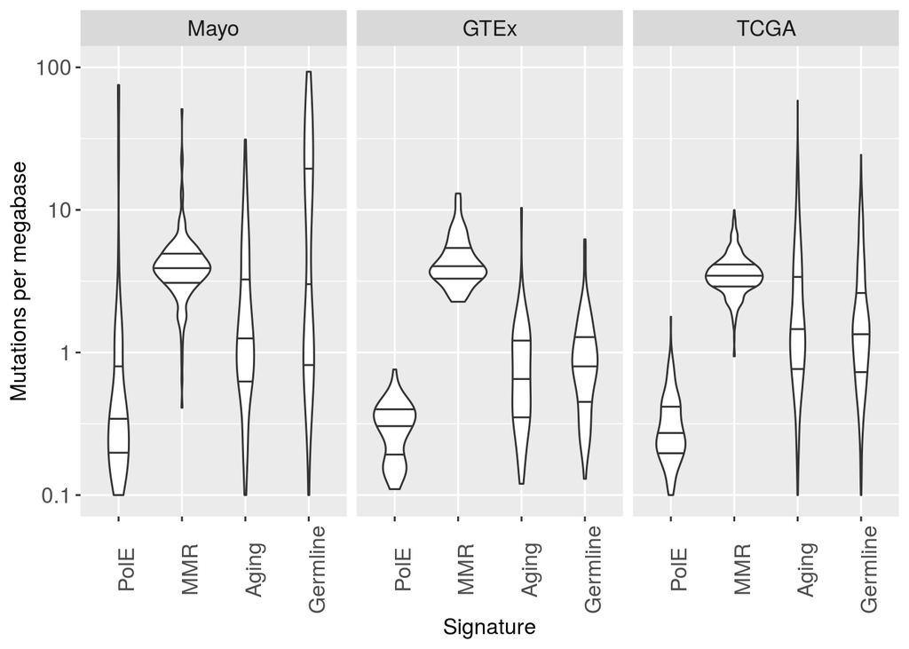

```r
study.order <- c("Mayo","GTEx","TCGA")
signature.order <-c("PolE","MMR","Aging","Germline")

sig.abs.contribution <- calc_abs_contribution (nmf.res,sig.names) %>%
    inner_join(sample.info) %>%
    mutate(pred.snvs=round(contribution*tmb,digits=2),
           study=ifelse(study=="Gtex","GTEx",study),
           study=factor(study,levels=study.order),
           signature=factor(signature, levels=signature.order))

ggplot(sig.abs.contribution,
       aes(x=signature,y=pred.snvs)) +
    geom_violin(draw_quantiles=c(0.25,0.5,0.75) )+
    facet_grid(.~study)+
    scale_y_log10(limits=c(0.1,100),
                  breaks=c(0.1,1,10,100),
                  labels=c("0.1","1","10","100"))+
    theme(axis.text.x = element_text(size=12, angle=90),
          axis.text.y = element_text(size=12),
          axis.title = element_text(size=12),
          strip.text.x = element_text(size=12))+
    labs(x="Signature",y="Mutations per megabase")
```

```r
ggsave("figures/supp.figure.1.png", units="in", dpi=300,
       scale=1, width=5, height=3 )
```

And calculate their medians and IQR below

```r
# Median across signatures and studies
knitr::kable(sig.abs.contribution %>%
    group_by(study,signature) %>%
    summarize (median.TMB = median(pred.snvs)) %>%
    pivot_wider(names_from=signature, values_from=median.TMB))
```

| study | PolE | MMR | Aging | Germline |
| --- | --- | --- | --- | --- |
| Mayo | 0.170 | 3.800 | 0.960 | 2.59 |
| GTEx | 0.125 | 3.875 | 0.495 | 0.72 |
| TCGA | 0.170 | 3.440 | 1.370 | 1.27 |

```r
# IQR across signatures and studies
knitr::kable(sig.abs.contribution %>%
    group_by(study,signature) %>%
    summarize (iqr.TMB = quantile (pred.snvs, c(.75))-
                   quantile(pred.snvs,c(.25))) %>%
    pivot_wider(names_from=signature, values_from=iqr.TMB))
```

| study | PolE | MMR | Aging | Germline |
| --- | --- | --- | --- | --- |
| Mayo | 0.375 | 1.830 | 2.14 | 25.4900 |
| GTEx | 0.310 | 1.945 | 0.89 | 0.8025 |
| TCGA | 0.285 | 1.155 | 2.53 | 1.6750 |

We assess the cosine similarity between the NMF reconstructed signatures and the original signatures

```r
sig.fit.contribution <- calc_fit_contribution (mut_mat, nmf.res)
knitr::kable(quantile(sig.fit.contribution$fit))
```

|  | x |
| --- | --- |
| 0% | 0.7240899 |
| 25% | 0.8888911 |
| 50% | 0.9183652 |
| 75% | 0.9350689 |
| 100% | 0.9742784 |

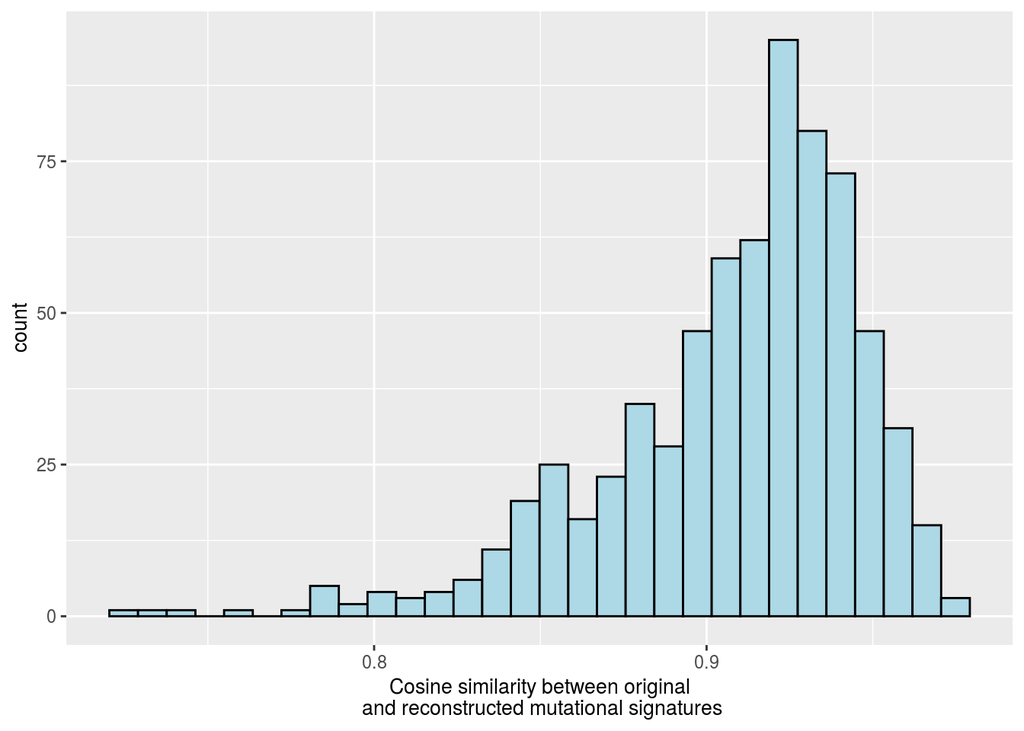

```r
ggplot(sig.fit.contribution, aes(x=fit))+
    geom_histogram(color="black", fill="lightblue")+
    labs(x="Cosine similarity between original\n and reconstructed mutational signatures")+
    theme(axis.title = element_text(size=10))
```

```r
ggsave("figures/supp.figure.2.png", units="in", dpi=300,
       scale=1, width=3, height=3 )
```

### Calculating somatic TMB

We can calculate the somatic TMB across samples by subtracting the contribution of the germline signature. Below we plot the distribution of TMB across studies

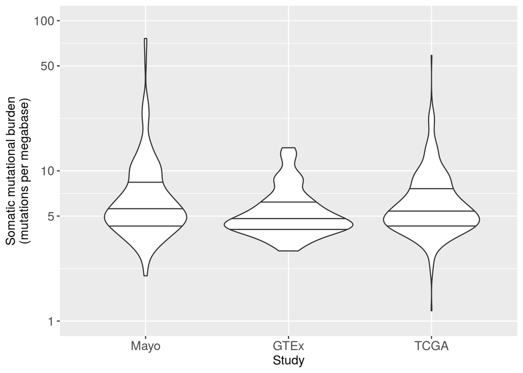

```r
mut.table <-  sig.abs.contribution %>%
    select (sample,signature,pred.snvs,study) %>%
    spread (signature,pred.snvs)%>%
    inner_join(sig.fit.contribution) %>%
    inner_join(sample.info, by = c("sample")) %>%
    mutate (tmb.norm=(MMR+PolE+Aging),
            adj.num = MMR + PolE + Aging + Germline,
            mmr.pct = MMR/adj.num,
            pole.pct = PolE/adj.num,
            study = study.x) %>%
    select (-c("study.y","study.x"))

mut.table = as_tibble(mut.table)

breaks.signatures = c(0.1,0.5,1,5,10,50,100)
labels.signatures = c("0.1","0.5","1","5","10","50","100")


# Supplementary figure with TMB distribution across studies
ggplot(mut.table, aes(x=study,y=tmb.norm))+
    geom_violin(draw_quantiles=c(0.25,0.5,0.75))+
    scale_y_log10(limits=c(1,100),
                  breaks=breaks.signatures,
                  labels=labels.signatures)+
    labs(x="Study",y="Somatic mutational burden\n(mutations per megabase)")+
    theme(axis.text.x = element_text(size=12),
          axis.text.y = element_text(size=12),
          axis.title = element_text(size=12),
          strip.text.x = element_text(size=12))
```

```r
ggsave("figures/supp.figure.4.png", units="in", dpi=300,
       scale=1, width=5, height=3 )


# Summary statistics of TMB across studies
knitr::kable(
  mut.table %>%
    group_by(study) %>%
    summarize (median.TMB = median(tmb.norm),
               iqr.TMB = quantile (tmb.norm, c(.75))-
                   quantile(tmb.norm,c(.25))))
```

| study | median.TMB | iqr.TMB |
| --- | --- | --- |
| Mayo | 5.450 | 4.02 |
| GTEx | 4.735 | 2.00 |
| TCGA | 5.350 | 3.21 |

### Identifying samples with high POLE signature contribution

We transform the table so that each mutational signature gets a different column

```r
mut.table <-  sig.abs.contribution %>%
    select (sample,signature,pred.snvs,study) %>%
    spread (signature,pred.snvs)%>%
    inner_join(sig.fit.contribution) %>%
    inner_join(sample.info, by = c("sample")) %>%
    mutate (tmb.norm=(MMR+PolE+Aging),
            adj.num = MMR + PolE + Aging + Germline,
            mmr.pct = MMR/adj.num,
            pole.pct = PolE/adj.num,
            study = study.x) %>%
    select (-c("study.y","study.x"))

mut.table = as_tibble(mut.table)
```

We plot the distribution of the POLE signatures across cohorts and label samples from the Mayo cohort with over 5 mutations per Mb

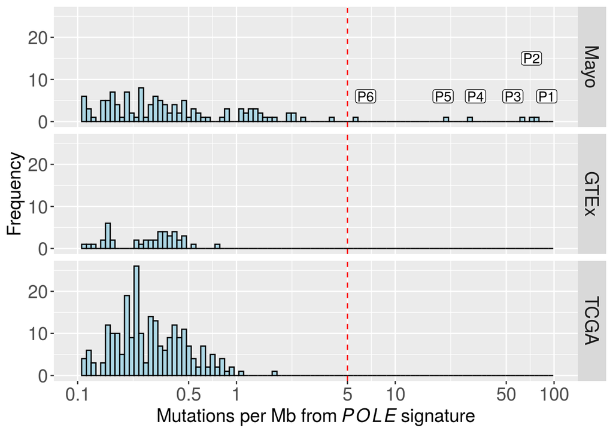

```r
pole.labels = mut.table %>%
    filter (PolE>5)%>%
    arrange(desc(PolE)) %>%
    mutate(id = paste0("P",row_number())) %>%
    select(sample,id,PolE,study)
adj.x = c(90,72,55,32,20,6.5)
adj.y = c(6,15,6,6,6,6)

pole.labels = pole.labels %>%
  add_column(x=adj.x, y=adj.y)

breaks.signatures = c(0.1,0.5,1,5,10,50,100)
labels.signatures = c("0.1","0.5","1","5","10","50","100")

pole.hist =
    ggplot(mut.table, aes(x=PolE))+
    geom_histogram(color="black",
                   fill="lightblue",
                   binwidth=0.03)+
    geom_vline(xintercept=5, linetype="dashed", color="red")+
    facet_grid(study~.)+
    scale_x_log10(limits=c(0.1,100),
                  breaks=breaks.signatures,
                  labels=labels.signatures)+
    labs(x=expression('Mutations per Mb from'~italic(POLE)~'signature'),
         y="Frequency")+
    geom_label(data=pole.labels,aes(label=id,x=x, y=y),
               size=4, label.padding=unit(0.1, "lines"))+
    theme(axis.text.x = element_text(size=15),
          axis.text.y = element_text(size=15),
          axis.title = element_text(size=15),
          strip.text.y = element_text(size=15))
pole.hist
```

And we plot the mutational profiles of these six outlier POLE samples

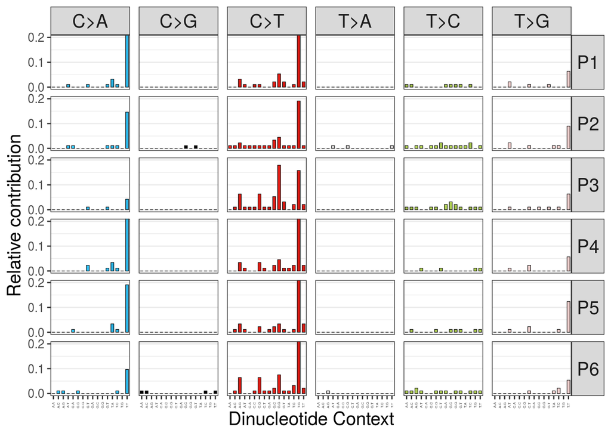

```r
pole.high=
    get_top_signature(mut.table, signatures, "PolE",top.n=6)+
    theme(axis.text.y = element_text(size=10),
          axis.text.x = element_text(size=3),
          axis.title = element_text(size=12),
          strip.text.y = element_text(size=15, angle=0),
          strip.text.x = element_text(size=15),
          axis.title.x = element_text(size=15),
          axis.title.y = element_text(size=15))+
    labs(x="Dinucleotide Context")

pole.high
```

```r
png ("figures/figure.2.png",
     width=5, height=7, units='in',
     res=300, pointsize=20)

ggarrange(
    pole.hist,
    pole.high,
    labels = c("A","B"),
    nrow=2, heights=c(0.8, 1.1))

dev.off()
```

Notice that sample P3 has high MMR component as well. By checking on IGV it was later found that it had mutation R167C in MLH1, so it is likely a Lynch Syndrome case as well.

```r
knitr::kable(
 mut.table %>%
    filter (PolE>5)%>%
    arrange(desc(PolE)) %>%
    mutate(id = paste0("P",row_number())) %>%
    filter(MMR>5)%>%
    select(id,PolE,MMR,tmb.norm,study))
```

| id | PolE | MMR | tmb.norm | study |
| --- | --- | --- | --- | --- |
| P3 | 64.13 | 50.88 | 115.01 | Mayo |

### POLE hotspot mutations

We can do a lollipop plot with the hotspot mutations from POLE across COSMIC

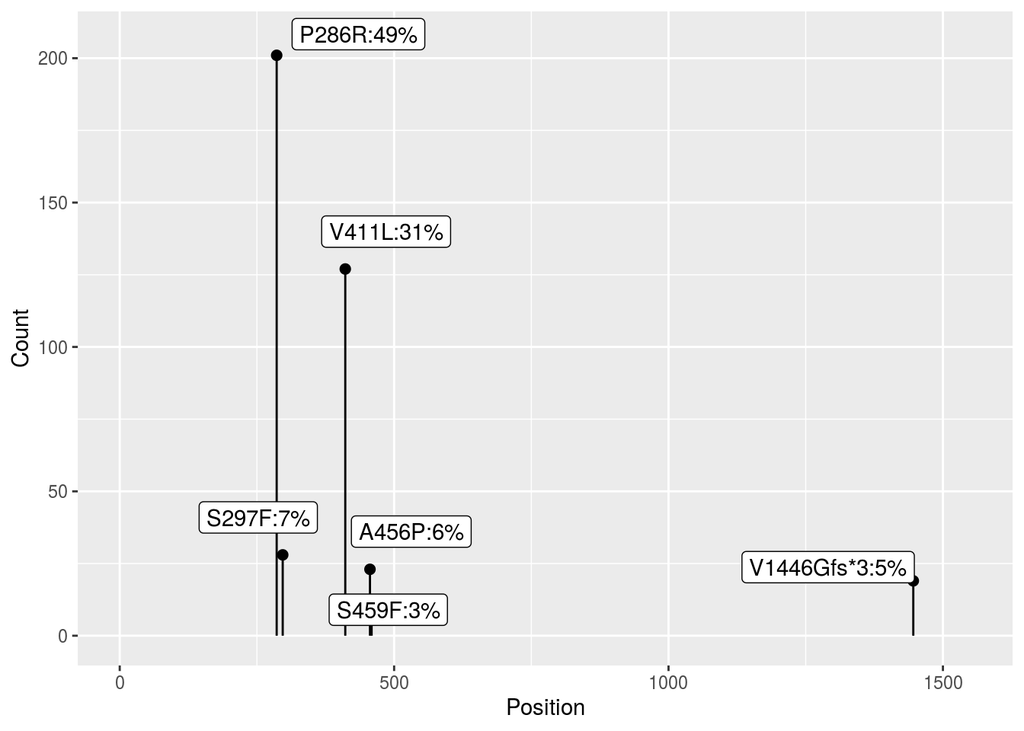

```r
pole.hotspot <- read_csv(
    "supplied_data/cosmic.pole.hotspot.csv") %>%
    filter(Count>=10) %>%
    mutate(pct= paste0(round(Count/sum(Count)*100, 0), "%"))

pole.hotspot.fig <-
  ggplot(data=pole.hotspot,
         aes(x=Position,y=Count))+
      geom_segment(aes(x=Position,y=0,
                     xend=Position,yend=Count))+
      geom_point (size=2)+
      geom_label_repel( aes(label=paste0(AA,":",pct,""),
                      x=Position+15,
                      y=Count+5))+
      xlim(1,1550)

pole.hotspot.fig
```

```r
png("figures/supp.figure.3.png", width=3, height=3,
    units="in", res=300, pointsize=15)

pole.hotspot.fig
dev.off()
```